# Index

Index 2022-11-06

### 1.Analisis de la data

Regresion: modelo 1

|  | Modelo 1 |
| --- | --- |
| (Intercept) | −1.618* |
|  | (0.675) |
| idh | 9.534*** |
|  | (0.910) |
| Num.Obs. | 153 |
| R2 | 0.421 |
| R2 Adj. | 0.417 |
| AIC | 612.2 |
| BIC | 621.3 |
| Log.Lik. | −303.079 |
| F | 109.665 |
| RMSE | 1.75 |

+ p < 0.1, * p < 0.05, ** p < 0.01, *** p < 0.001

El analisis de la primera regresión refleja que la variable IDH impacta de forma significativa y positivamente en la variable democracia, esto quiere decir que a mayor score de idh mayor democracia. El r cuadrado indica que este modelo no tiene una explicación signiifcativa de la variabilidad ya que es de 0.4, por lo tanto no es un buen modelo.

Regresion: modelo 2

|  | Modelo 2 |
| --- | --- |
| (Intercept) | −8.282*** |
|  | (1.374) |
| idh | 6.594*** |
|  | (0.992) |
| genero | 12.697*** |
|  | (2.212) |
| Num.Obs. | 136 |
| R2 | 0.529 |
| R2 Adj. | 0.522 |
| AIC | 511.9 |
| BIC | 523.6 |
| Log.Lik. | −251.955 |
| F | 74.704 |
| RMSE | 1.54 |

+ p < 0.1, * p < 0.05, ** p < 0.01, *** p < 0.001

El modelo de idh y genero impactan de forma signiifcativa y positivamente en la variable democracia  
A diferencia del primer modelo, al incluir la variable genero el porcentaje de variable aumenta en 0.1, lo cual refleja que el porcentaje de explicacion de varibilidad en este modelo incrementa, por lo tanto es mejor que el modelo anterior.

Regresion: modelo 3

|  | Modelo 3 |
| --- | --- |
| (Intercept) | −8.320*** |
|  | (1.345) |
| idh | 10.446*** |
|  | (1.488) |
| genero | 14.176*** |
|  | (2.207) |
| alfabetizacion | −0.044*** |
|  | (0.013) |
| Num.Obs. | 135 |
| R2 | 0.558 |
| R2 Adj. | 0.548 |
| AIC | 499.1 |
| BIC | 513.6 |
| Log.Lik. | −244.560 |
| F | 55.156 |
| RMSE | 1.48 |

+ p < 0.1, * p < 0.05, ** p < 0.01, *** p < 0.001

En el Modelo 3 el valor del r2 no aumenta de forma significativa, por lo tanto la explicacion de la variabilidad del modelo se mantiene en 50%. Sin embargo, se observa que la varible genero tiene un impacto mayor al de las varibales idh y alfabetizacion, esto refleja que tiene un efecyo significativo y positivo en el índice de democracia.

Resultados de todos los modelos

|  | Modelo 1 | Modelo 2 | Modelo 3 |
| --- | --- | --- | --- |
| (Intercept) | −1.618* | −8.282*** | −8.320*** |
|  | (0.675) | (1.374) | (1.345) |
| idh | 9.534*** | 6.594*** | 10.446*** |
|  | (0.910) | (0.992) | (1.488) |
| genero |  | 12.697*** | 14.176*** |
|  |  | (2.212) | (2.207) |
| alfabetizacion |  |  | −0.044*** |
|  |  |  | (0.013) |
| Num.Obs. | 153 | 136 | 135 |
| R2 | 0.421 | 0.529 | 0.558 |
| R2 Adj. | 0.417 | 0.522 | 0.548 |
| AIC | 612.2 | 511.9 | 499.1 |
| BIC | 621.3 | 523.6 | 513.6 |
| Log.Lik. | −303.079 | −251.955 | −244.560 |
| F | 109.665 | 74.704 | 55.156 |
| RMSE | 1.75 | 1.54 | 1.48 |

+ p < 0.1, * p < 0.05, ** p < 0.01, *** p < 0.001

En la comparación de los modelos realizados se puede observar que el modelo 3, el cual incluye a todas las variables independientes es el mejor modelo para explicar la variabilidad, y se confirma que la variable genero tiene una infliuencia significativa en el analisis y la varible con efcto menos dignificativo sobre el indice de democracia es la alfabetización.

### 2. Analisis Factorial

El indice de democracia explicado en base de las variables de IDH, genero y alfabetizaciòn, sin tomar en cuenta componentes exogenos y otras variables que puedan aportar en la efa, comprenden un resumen de un conjunto de varibles sí mismos, por lo tanto el analisis factorial exploratorio no explicaria los factores que se necesitan para completar el analisis.

### 3. Analisis de Conglomerados

Se solicitan 3 clusters y se realiza el analisis a través de PAM

|  | democracia | idh | genero | alfabetizacion | pam |
| --- | --- | --- | --- | --- | --- |
| Afghanistan | 0.32 | 0.478 | 0.444 | 38.1680 | 1 |
| Albania | 6.11 | 0.796 | 0.770 | 97.5539 | 2 |
| Algeria | 3.77 | 0.745 | 0.633 | 79.6084 | 2 |
| Angola | 3.37 | 0.586 | 0.657 | 71.1642 | 1 |
| Argentina | 6.81 | 0.842 | 0.752 | 98.0900 | 3 |
| Armenia | 5.49 | 0.759 | 0.673 | 99.7684 | 2 |
| Australia | 8.90 | 0.951 | 0.731 | 99.0000 | 3 |
| Austria | 8.07 | 0.916 | 0.777 | 98.0000 | 3 |
| Azerbaijan | 2.68 | 0.745 | 0.688 | 99.8053 | 2 |
| Bahrain | 2.52 | 0.875 | 0.632 | 95.7173 | 2 |
| Bangladesh | 5.99 | 0.661 | 0.719 | 61.4938 | 2 |
| Belarus | 2.41 | 0.808 | 0.758 | 99.7220 | 2 |
| Belgium | 7.51 | 0.937 | 0.789 | 99.0000 | 3 |
| Benin | 4.19 | 0.525 | 0.653 | 38.4471 | 1 |
| Bhutan | 5.71 | 0.666 | 0.639 | 63.9068 | 2 |

Se observan los paises con menor indice de democracia fuera de la clusterización

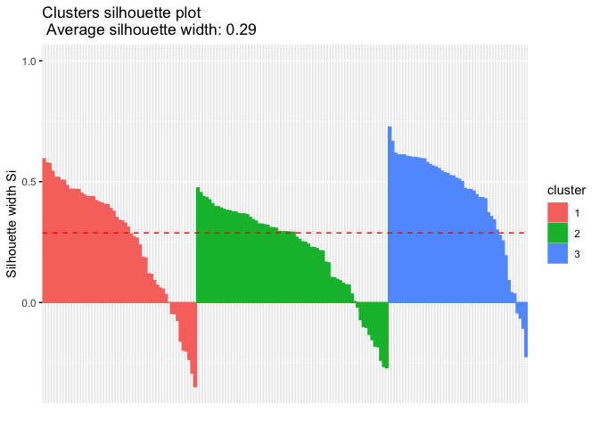

Características de cada conglomerado:

```
##   pam democracia       idh    genero alfabetizacion
## 1   1   3.163636 0.5443636 0.6591212       64.18668
## 2   2   5.203000 0.7528833 0.6994833       92.03235
## 3   3   8.066667 0.8751190 0.7585000       96.89832
```

### 4.Mapa

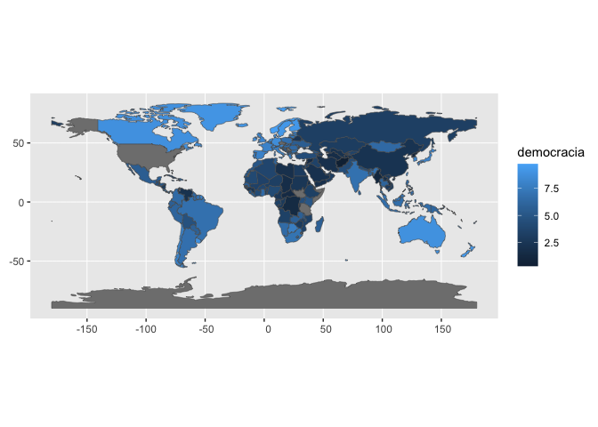

En el mapa se puede observar que los paìses con indices de democracia mas bajos, con un valor de 5.0< con mayoritarios y son de color azul oscuro y los paises con mayores indices de democracia, con valor mayor a 5.0 se concentran en America, Ocenia y Europa.